# Project Report: Association between Gross Domestic Product and US Interest Rate

3/10/2016

# 1 Introduction

- This report will try to find an association between gross domestic product(GDP) and interest rate and explain how they are related to each other using time series analysis.
- Intuitively, the GDP represents the economic growth in the country and the Federal Reserve System usually raises interest rate when economic booms.
- Albu and Ghizdeanu(2008) pointed out that there is a positive relationship between interest rate, investment and gross domestic product(GDP) [1]. It suggests that GDP and interest rate usually rise together, as demands for runds increase.

# 2 Data Sources

- I am going to use the Interest Rate data set from the United States Federal Reserve System [2].
- It is a collection of daily interest rate for United States from 1954-07-01 to 2016-03-03.

```
##          date inte
## 6  1954-07-01 1.13
## 7  1954-07-02 1.25
## 8  1954-07-03 1.25
## 9  1954-07-04 1.25
## 10 1954-07-05 0.88
## 11 1954-07-06 0.25
```

- The variable `inte` is the interest rates that we are interested in. The unit is percent per year.

```
##          date    ex
## 11 1947-01-01 243.1
## 12 1947-04-01 246.3
## 13 1947-07-01 250.1
## 14 1947-10-01 260.3
## 15 1948-01-01 266.2
## 16 1948-04-01 272.9
```

- The above time series data set is a collection of quarterly GDP data for the United States.
- The `ex` column records quarterly GDP in US. GDP is the market value of the goods and services produced by labor and property [3].
- Write ${i_n^*}$ for interest rate in the $t_n=n$ th quarter.
- Write ${g_n^*}$ for GDP in quarter $t_n$.
- I use R to get the mean quarterly data for interst rate and combine these two data sets.
- In the combined data set, we have time series data from Year 1954 3rd quarter to Year 2015 4th Quarter.

# 3 Exploratory Data Anlaysis

## 3.1 Time Series Plot

- I start from making a time series plot to see how the data sets look like.

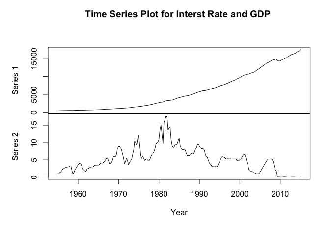

Figure 1. Time Series Plot for GDP (top) and interest rate (bottom).

- From the time series plot, we can see that GDP (top plot) is overrall growing for the past 50 years.
- However, before the year 2010, the GDP decelerated. It reminds us of the 2008 Financial Crisis that stroke the financial market and stopped the economic growth.
- The interest rate (bottom plot) seems to fluctuate for past years. It was first raised for the first few years and peaked around year 1982. Then it was lowered rapidly around 1993, 2002 and 2008. Now it is approimately on the same level as 1950s.

## 3.2 Detrended Time Series Plot

- To see if GDP and interest rate cycle together, we first remove trends from these two time series. We use the Hodrick-Prescott method for filtering.
- As suggested by Hodrick and Prescott, I use 1600 as a smoothing parameter for $\lambda$ for the quarterly data [4].
- Define the HP-detrended GDP to be $g^{HP*}_{1:N}$, and detrended interest rate to be $i^{HP*}_{1:N}$.

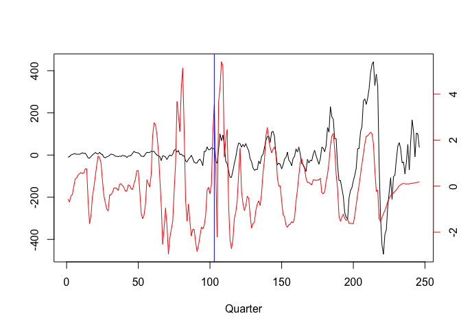

Figure 2. Detrended GDP (black; left axis) and detrended interest rate (red; right axis).

- From this detrended plot, we can see that the detrended GDP and detrended interest rate cycle together, especially after the 100th quarter. It is around the year 1980.
- Before the year 1980, we can see that they also cycle mostly together with ups and downs, but it is not strong enough to see that from the plot. The black lines (GDP) is more stable compared with the red lines (interest rates).
- Due to extreme situations such as American Civil War and War in Vietnam, the data before 1980s are acting abnormal, especially for the detrended interest rate. It fluctuates heavily with rapid rise and decline. Since we are interested in association betweeen GDP and interest under stable economy market, we only use the data after the vertical line (quarters from 1980 to 2015, which is under economy market) for further exploratory data analysis and regression modeling.

## 3.3 Spectral Analysis

- Then I take a look at the spectrum of these two detrended data sets to study the frequency and cycles.

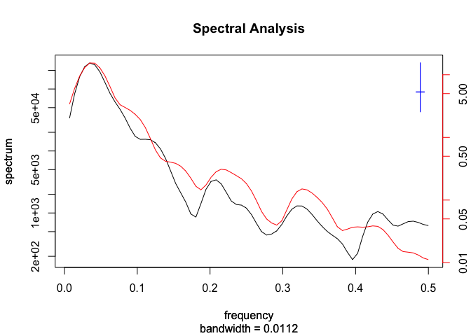

Figure 3. Spectrum Plot for Detrended GDP (black; left axis) and detrended interest rate (red; right axis).

- The spectrum of a time series is the distribution of variance of the series as a function of frequency.
- The unit of the x axis is cycles per quarter. The dominant frequencies for both detrended data are around 0.04 cycles per quarter. It is consistent with our time series plot, which shows a dominnant 25-quarter cycle after 1980.
- The spectrum plot looks approximately alike when the frequency is low. It also supports our hypothesis that GDP and interest rate are associated with each other.

# 4 Time Series Model

- From our exploratory data analysis, we see that there is a association between detrended GDP and detrended intereste rate. Then, I want to check this association by fitting a linear regression model with arma errors.

$$g^{HP}_n = \alpha + \beta i^{HP}_n + \epsilon_n,$$
where $\{\epsilon_n\}$ is a Gaussian ARMA process.

## 4.1 Model selection by AIC

|  | MA0 | MA1 | MA2 | MA3 | MA4 | MA5 |
| --- | --- | --- | --- | --- | --- | --- |
| **AR0** | 1800.12 | 1692.91 | 1635.69 | 1619.57 | 1596.00 | 1585.27 |
| **AR1** | 1598.40 | 1591.62 | 1590.40 | 1590.21 | 1580.33 | 1582.02 |
| **AR2** | 1587.80 | 1567.66 | 1592.98 | 1594.26 | 1581.94 | 1583.30 |
| **AR3** | 1585.38 | 1568.55 | 1570.53 | 1572.21 | 1583.91 | 1585.91 |
| **AR4** | 1584.24 | 1570.54 | 1585.64 | 1562.39 | 1564.38 | 1579.50 |

- The AIC table suggests using the model with ARMA(2,1) errors.
- There are models with smaller AIC values such as ARMA(4,4). However, we need to treat it with caution and pick the best small model.

```
##
## Call:
## arima(x = ex_hp, order = c(2, 0, 1), xreg = in_hp)
##
## Coefficients:
##          ar1      ar2      ma1  intercept    in_hp
##       1.8621  -0.9111  -1.0000    -0.0991  14.9162
## s.e.  0.0307   0.0306   0.0189     2.0991   5.6216
##
## sigma^2 estimated as 2772:  log likelihood = -777.83,  aic = 1567.66
```

- The standard error for $\beta$ computed by the observed Fisher inforamtion suggest a significant positive association between cyclical variation in detrended GDP and detrended interest rate.

## 4.2 p-value

- I can also use the likelihood ratio test to check the p value for nested hypotheses
- The model I have fitted is
  $$(1-{\phi}_1 B)(1-{\phi}_2 B^2)(g^{HP}_n - \alpha - \beta i^{HP}_n) = \epsilon_n(1+{\psi}_1 B),$$
  where ${\epsilon_n}$ is Gaussian white noise with variance $\sigma^2$.
  The null hypothesis is
  $$\begin{eqnarray} H^{\langle 0\rangle} &:& \beta =0 \end{eqnarray}$$
  The alternative hypothesis is
  $$\begin{eqnarray} H^{\langle 1\rangle} &:& \beta\ne 0, \end{eqnarray}$$
- The likelihood ratio test gives a p value of 0.0035. So we reject the null hypothesis, which indicates an association between detrended GDP and detrended interest rate.

## 4.3 Residual analysis

### 4.3.1 Residual Plot

- First, we check the residual of our regression model to see if there exists heteroskedasticity.

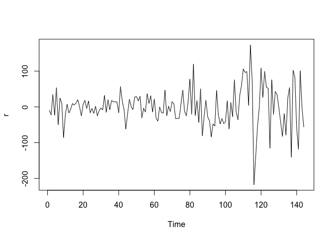

Figure 4. Residual Plot.